# Laporan Praktikum Pertemuan 4

Pembangkitan Data ARMA — MA(2), AR(2), dan ARMA(2,2)

NamaM Dava Arya Permadi

NIMX1004261009

Laporan ini dibangkitkan ulang dari skrip `Latihan_Pert4_MA2_AR2_ARMA22.R` menggunakan Python (NumPy & statsmodels) di lingkungan kerja ini karena R tidak tersedia untuk dijalankan langsung. Logika pembangkitan (rumus rekursif, parameter, dan panjang data `n = 300`) mengikuti skrip asli persis; hanya generator bilangan acaknya yang berbeda dari R, sehingga angka empiris bisa sedikit berbeda dari hasil `Rscript` Anda namun pola dan kesimpulannya identik. Fungsi `eacf()` (paket TSA di R) tidak memiliki padanan langsung di Python, sehingga bagian tersebut digantikan dengan pembacaan pola ACF/PACF di atas.

## 1. Proses MA(2)

θ₁ = 0.4, θ₂ = 0.6 | y_t = e_t + θ1·e_(t-1) + θ2·e_(t-2)

### Plot Time Series

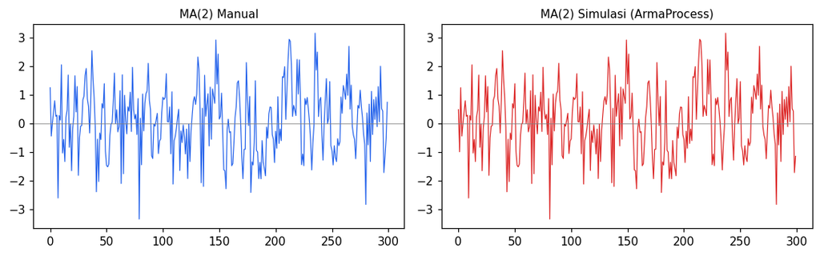

Kedua deret berfluktuasi di sekitar rataan konstan (~0) tanpa tren → stasioner dalam rataan.

### Plot ACF

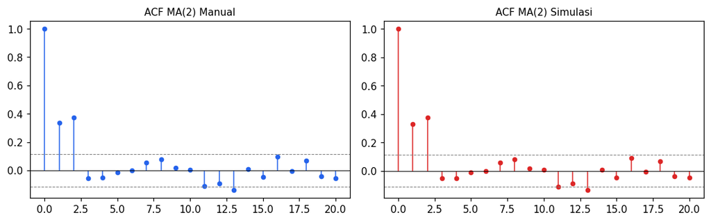

Untuk MA(2), ACF teoritis **cut off** setelah lag ke-2.

### Plot PACF

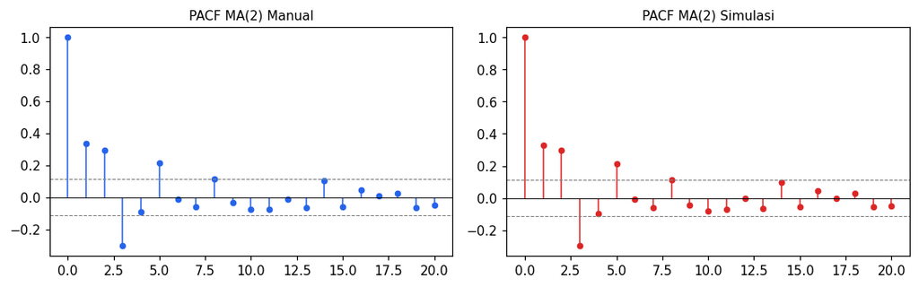

PACF proses MA akan **tails off** (meluruh berangsur).

### Scatterplot Antar Lag

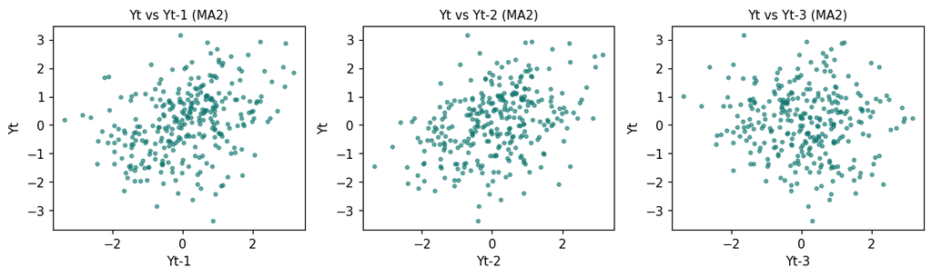

### Perbandingan Autokorelasi: Empiris vs Teoritis

| Lag | Empiris | Teoritis |
| --- | --- | --- |
| 1 | 0.3392 | 0.4211 |
| 2 | 0.3747 | 0.3947 |
| 3 | -0.0576 | 0.0000 |

Rumus teoritis: rho1=(theta1+theta1*theta2)/(1+theta1^2+theta2^2), rho2=theta2/(1+theta1^2+theta2^2), rho_k=0 untuk k≥3.

## 2. Proses AR(2)

φ1 = 0.5, φ2 = 0.2 | y_t = φ1·y_(t-1) + φ2·y_(t-2) + e_t

### Plot Time Series

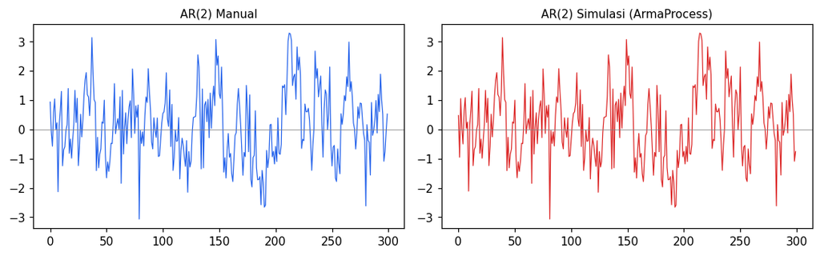

φ1+φ2 = 0.7 < 1 → memenuhi syarat kestasioneran AR(2); data berfluktuasi stabil di sekitar rataan.

### Plot ACF

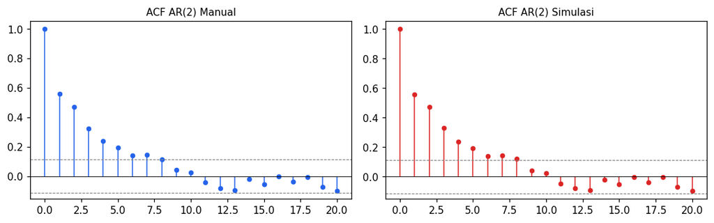

ACF proses AR akan **tails off** (meluruh eksponensial/sinusoidal).

### Plot PACF

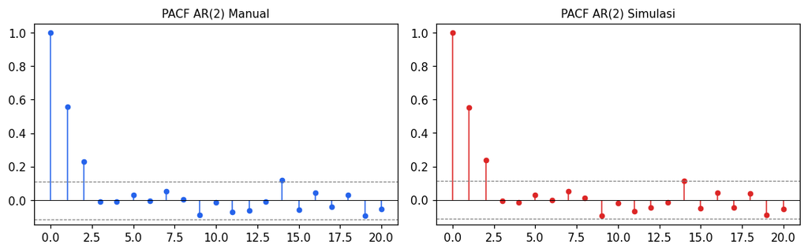

PACF proses AR(2) **cut off** setelah lag ke-2.

### Scatterplot Antar Lag

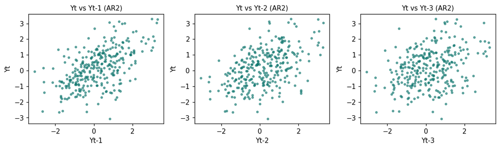

### Perbandingan Autokorelasi: Empiris vs Teoritis

| Lag | Empiris | Teoritis |
| --- | --- | --- |
| 1 | 0.5605 | 0.6250 |
| 2 | 0.4734 | 0.5125 |
| 3 | 0.3263 | 0.3812 |

Rumus Yule-Walker: rho1=phi1/(1-phi2), rho2=phi2+phi1^2/(1-phi2), rho_k=phi1*rho_(k-1)+phi2*rho_(k-2) untuk k≥3.

## 3. Proses ARMA(2,2)

θ1=0.4, θ2=0.6, φ1=0.5, φ2=0.2 | y_t = φ1y_(t-1)+φ2y_(t-2)+e_t+θ1e_(t-1)+θ2e_(t-2)

### Plot Time Series

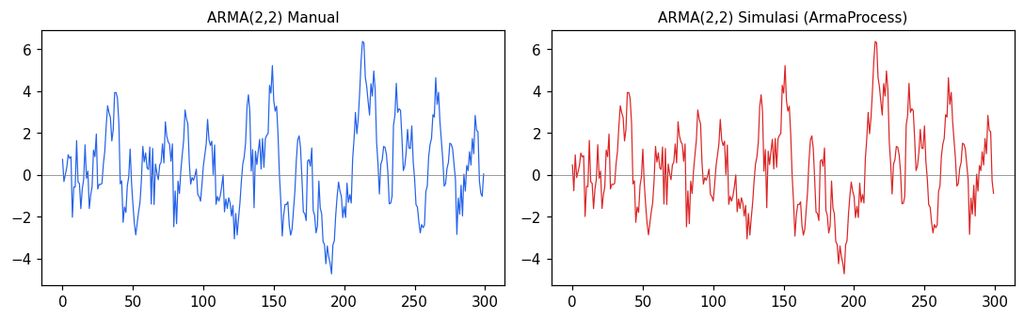

Komponen AR memenuhi syarat kestasioneran (φ1+φ2=0.7<1) sehingga data cenderung stasioner dalam rataan.

### Plot ACF

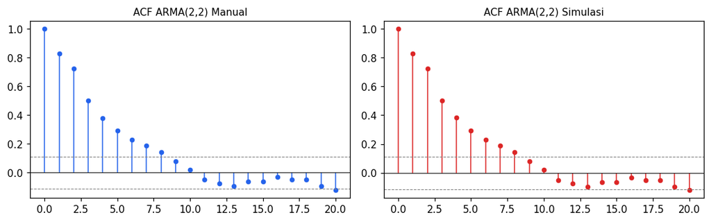

ACF proses ARMA akan **tails off**.

### Plot PACF

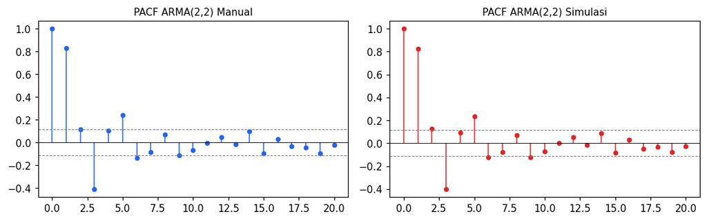

PACF proses ARMA juga akan **tails off** (tidak cut off tegas).

### Scatterplot Antar Lag

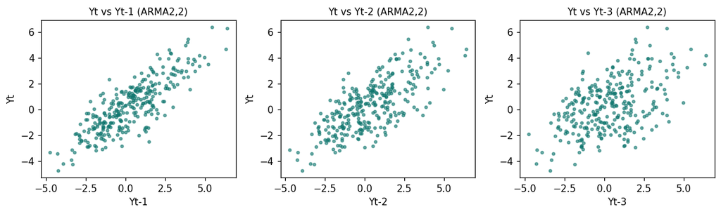

### Perbandingan Autokorelasi: Empiris vs Teoritis

| Lag | Empiris | Teoritis |
| --- | --- | --- |
| 1 | 0.8296 | 0.8592 |
| 2 | 0.7246 | 0.7492 |
| 3 | 0.5015 | 0.5464 |

Nilai teoritis dihitung memakai fungsi bawaan (setara ARMAacf di R / arma_acf di statsmodels), karena turunan manualnya melibatkan sistem persamaan yang panjang.

## Ringkasan

Perbandingan pola teoritis identifikasi model berdasarkan ACF/PACF:

| Proses | ACF | PACF |
| --- | --- | --- |
| MA(2) | Cut off setelah lag 2 | Tails off |
| AR(2) | Tails off | Cut off setelah lag 2 |
| ARMA(2,2) | Tails off | Tails off |

Pola inilah yang menjadi dasar identifikasi order model ARIMA/ARMA pada data deret waktu di praktik nyata (dikombinasikan dengan EACF untuk memastikan orde p dan q secara bersamaan).